# Areal Temperal Regression and S-T Kriging

June 4, 2015

In this section, the framework is carried out by: 1. applying Time series prediction over each district/beat; 2. analyzing and fitting the spatio-temporal variograms of the residuals from time series models; 3. predicting the residuals (interpolating in a finer spatial grid and exterpolating in time dimension); 4. summing up the predictions from step 1 and 3 to get the final predictions.

```
## with 288 features and 3 fields
## Feature type: wkbPolygon with 2 dimensions
```

```
## with 28 features and 3 fields
## Feature type: wkbPolygon with 2 dimensions
```

After loading crime and weather data (2008/01/01-2014/12/31), we fit a temporal model which is specified below for every beat/district.

The temporal model specifications:

1. fit the long term trend.
2. get the residuals from the trend fitting and do regression with variables (DOW,weather) using the Lasso.

Note: we do not include lagged variables here so that the temporal autocorrelations would be modelled by Kriging in the following stage.

We plot the city-wide spatio-temporal variograms. For computational reasons, here we only pool data over 08/01/2013-07/31/2014 and consider time lag up to 14 days. The beat-level and district-level spatio-temporal variograms of temporal model residuals are shown below.

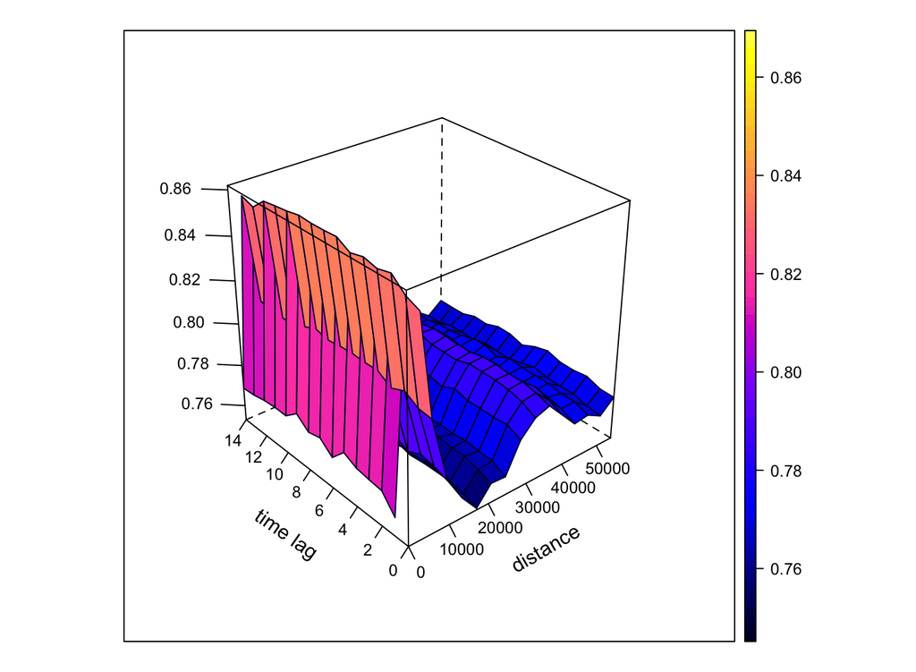

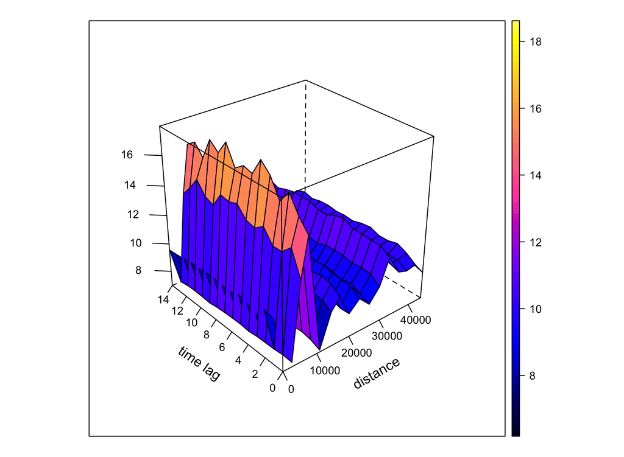

In order to see if which variogram model type (metric, separable or product-sum) is more suitable, we marginalize the data over space and time respectively and plot their variogram clouds and variograms.

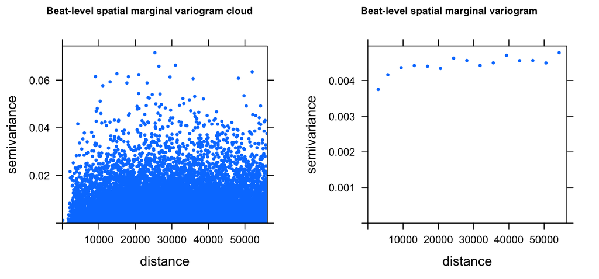

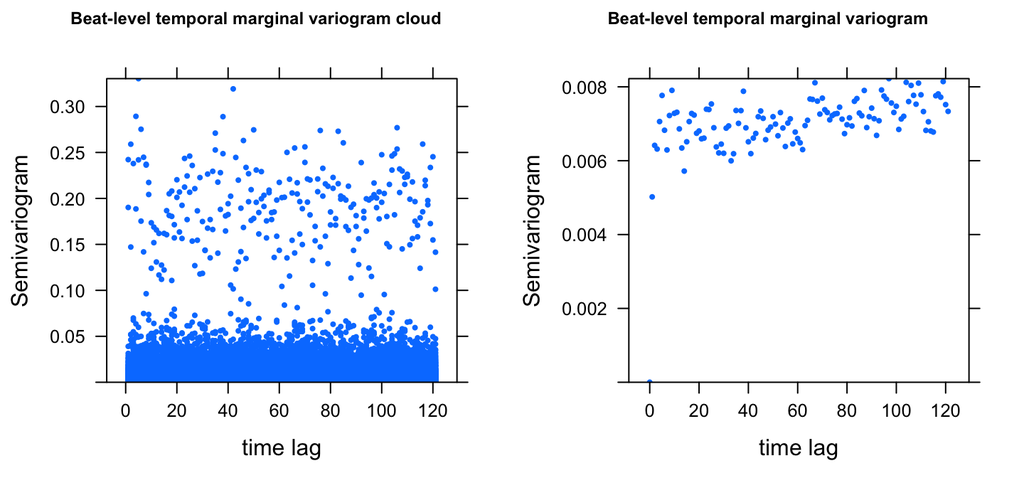

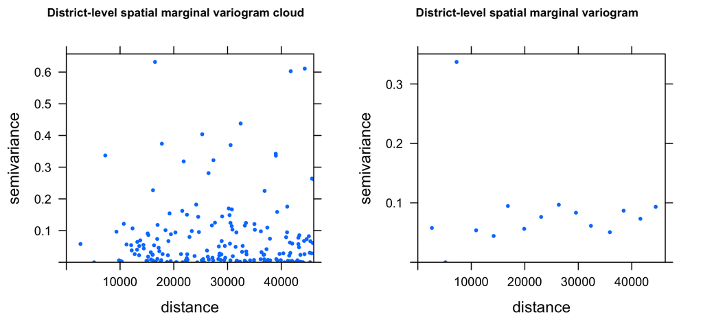

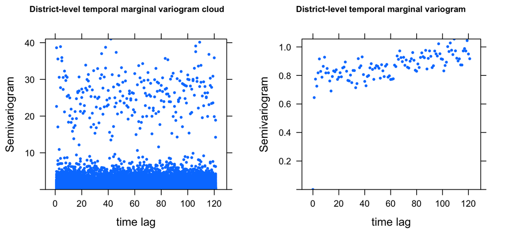

Then we fit the variogram by different types of ST variogram.

NOTE:

1. For the “metric” model, the spatio-temporal distance ratio is set to 2500
2. the nonlinear fitting (in least squares sense) is sensitive to the initial values as well as the optimization methods (here we apply L-BFGS)

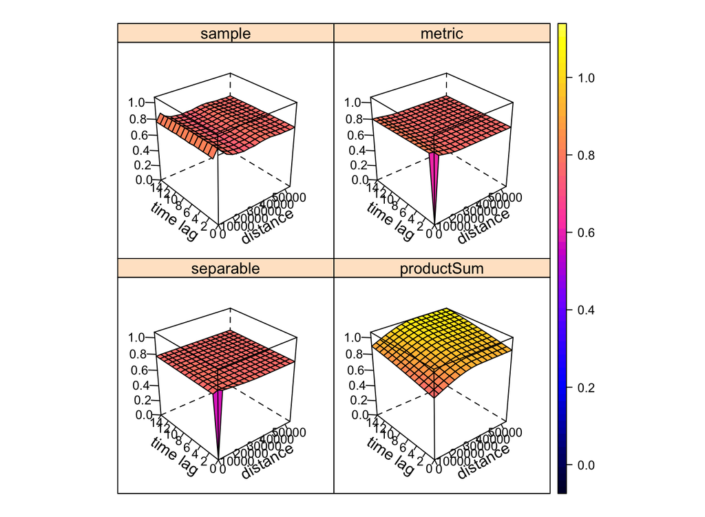

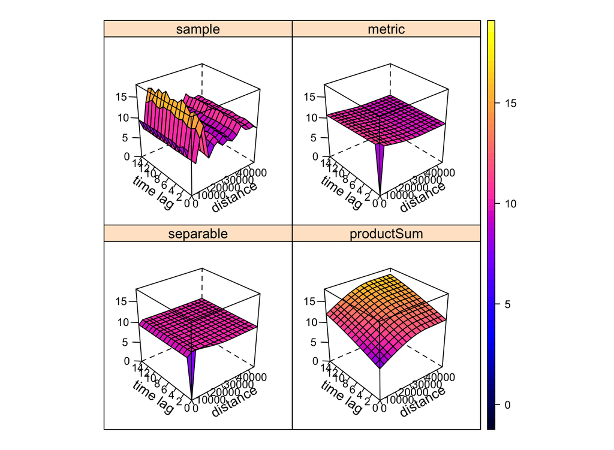

The poorly fitting results imply that we should do a “moving window” and dig into local variogram instead of estimating a pooled global variogram. This non-stationarity needs further research work.

For now, let us stick with the global estimated variogram. We would like to predict next two day’s violent crime distribution. The spatial interpolation was done over a $100 \times 100$ regular grid within the city border.

Since some the variogram fittings yield quite flat surface, the corresponding covariance matrices are not be positive definte (A variogram model that does not discriminate observations sufficiently, leading to near-perfectly correlated observations.). Here we adjust the intial values of the nonlinear fitting for the product-sum model so that it is positive definite, even though the it was not the best in terms of MSE.

Again, although the S-T variogram was estimated globally, when computing the convariance matrix inserse, only 200 local (in terms of distance) entries are taken into account for computational consideration.

```
##     user   system  elapsed
## 76039.83 14716.57 90867.33
```

```
##     user   system  elapsed
## 7945.205 1159.309 9104.622
```

Display the prediction results which are the summation of the temporal model predictions and the residual Kriging prediction, overlayed by the acutal incidents. For completeness, the time series predictions and the corresponding residual kriging predictions are also shown below.

Beat level:

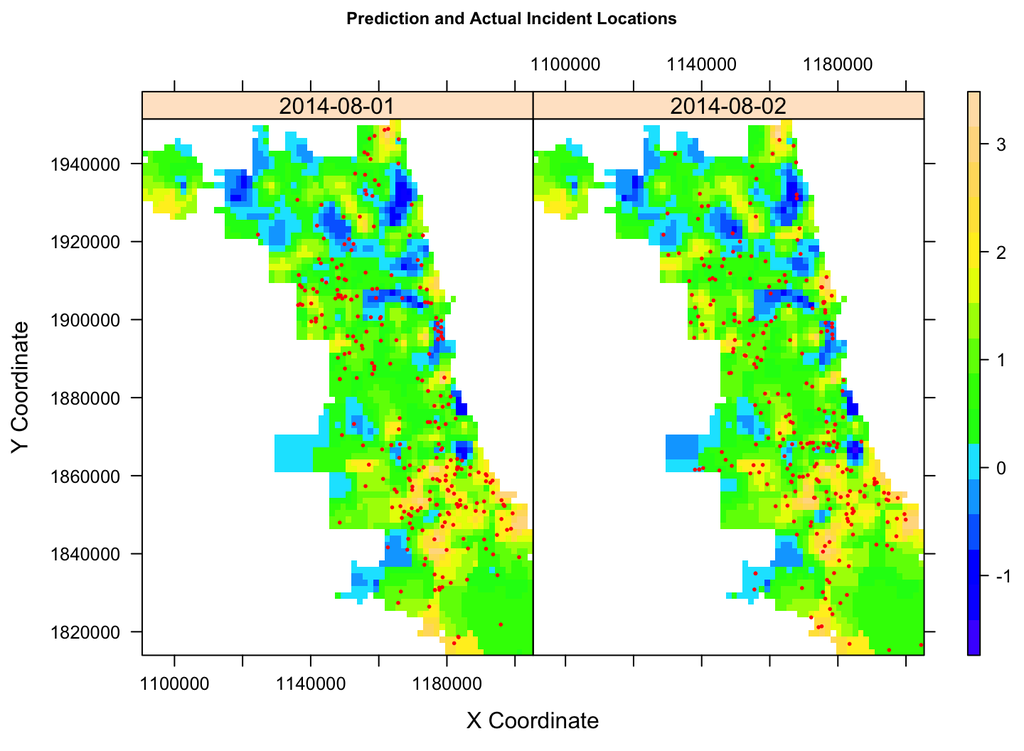

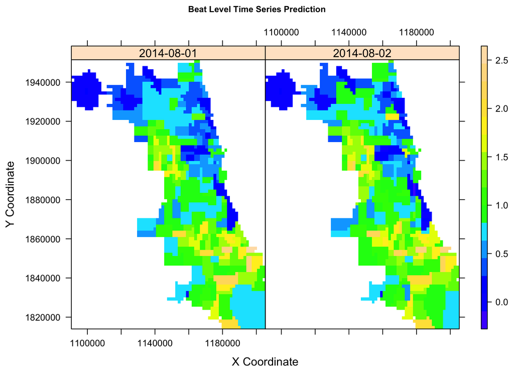

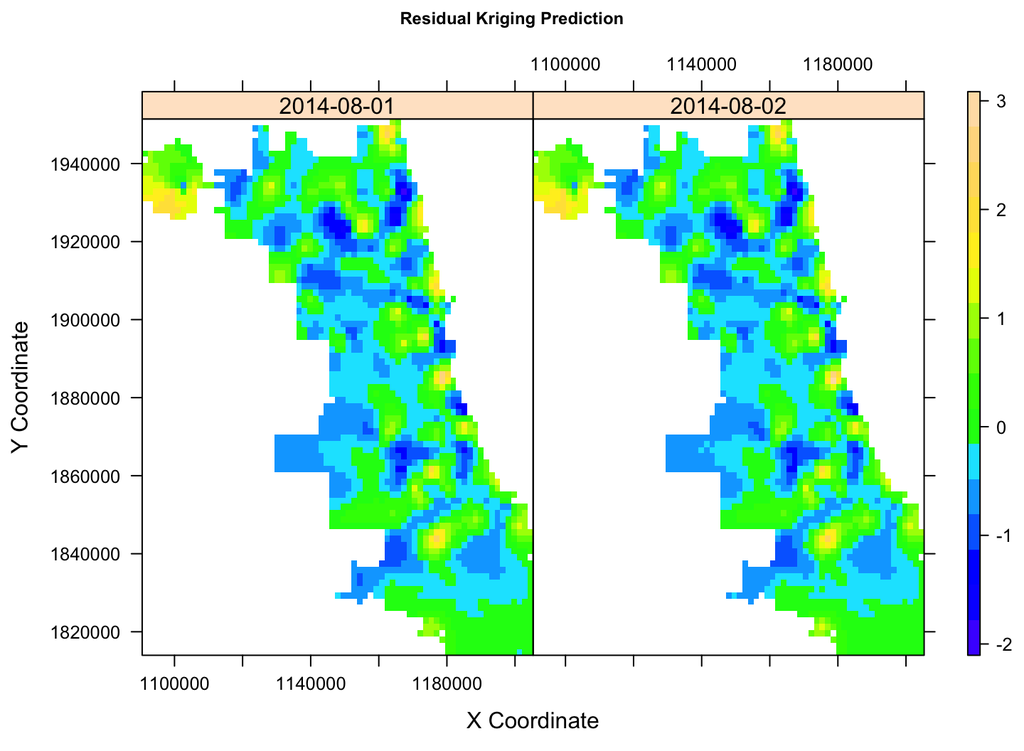

District level:

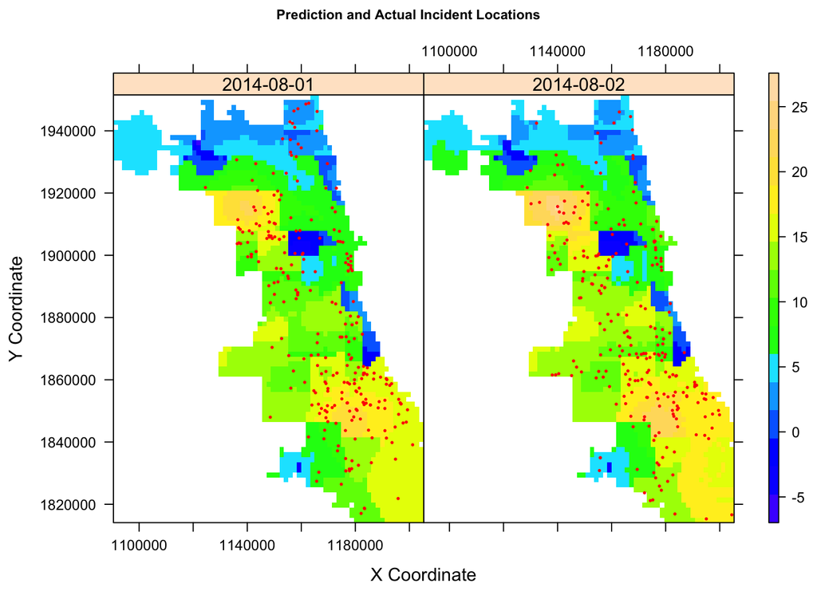

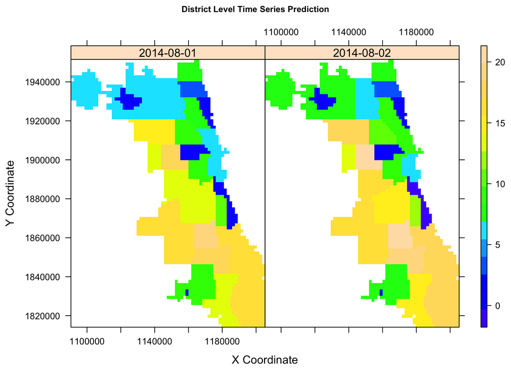

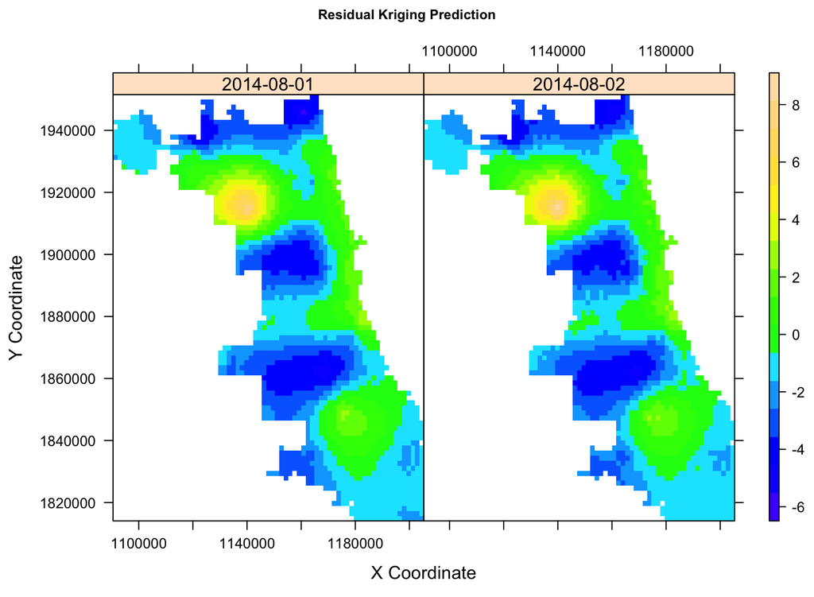